# Applied Machine Learning 410

Justin Donaldson  
March-09-2017

## Decision Trees and Random Forests

(AKA: divide and concur)

### Setup

```r
opts_chunk$set(out.width='700px', dpi=200,cache=TRUE, fig.width=10, fig.height=8 )
options(width =1960)
local({r <- getOption("repos")
       r["CRAN"] <- "http://cran.r-project.org"
       options(repos=r)
})
library(ggdendro)
library(tree)
library(ggplot2)
library(GGally)
library(randomForest)
library(ggmosaic)
library(reshape2)
library(rpart)
library(caret)
library(e1071)
```

### A Random Forest

## (Question - Is it Fall Yet?)

[figure not shown]

Black Rock Forest view from NE - Daniel Case

## Overview

- Why Random Forests?
- Why Decision Trees?
- Recap of Decision Trees
- Recap of Random Forests

## Why Random Forests?

### Why Random Forests?

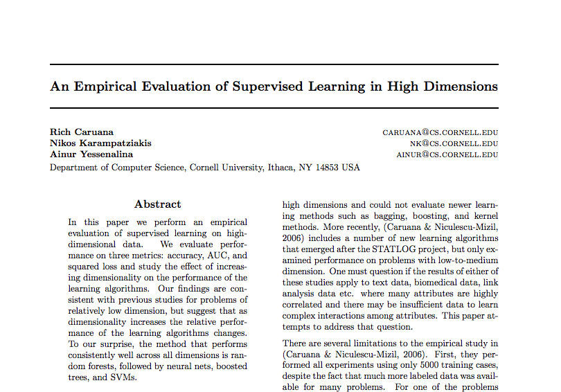

## Comparison of:

- Support Vector Machines
- Artificial Neural Networks
- Logistic Regression
- Naive Bayes
- K-Nearest Neighbors
- Random Forests
- Bagged Decision Trees
- Boosted Stumps
- Boosted Trees
- Perceptrons

### Why Random Forests?

## Evaluation Data Sets:

- Sturn, Calam : Ornithology
- Digits : MNIST handwritten
- Tis : mRNA translation sites
- Cryst : Protein Crystallography
- KDD98 : Donation Prediction
- R-S : Usenet real/simulation
- Cite : Paper Authorship
- Dse : Newswire
- Spam : TREC spam corpora
- Imdb : link prediction

## Error Metrics:

- AUC : Area under curve
- ACC : Accuracy
- RMS : Root Mean Squared Error

### Why are Random Forests useful?

## Conclusions

- Boosted decision trees performed best when < 4000 dimensions
- Random forests performed best when > 4000
  - Easy to parellize
  - Scales efficiently to high dimensions
  - Performs consistently well on all three metrics
- Non-linear methods do well when model complexity is constrained
- Worst performing models : Naive Bayes and Perceptrons

### What are Random Forest Drawbacks?

- Less interpretable than trees
- Model size can become cumbersome

### Why are Ensembles Better?

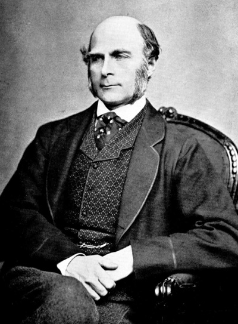

[figure not shown]

## Sir Francis Galton

- Promoted Statistics and invented correlation
- In 1906 visited a livestock fair and stumbled on contest
- An ox was on display, villagers were invited to guess its weight
- ~800 made guesses, but nobody got the right answer (1,198 pounds)
- The average of the guesses came very close! (1,197 pounds)

### An Intro to Decision Trees

## Quick interactive intro

> Machine learning explained in interactive visualizations (part 1) http://t.co/g75lLydMH9 [#d3js](https://twitter.com/hashtag/d3js?src=hash) [#machinelearning](https://twitter.com/hashtag/machinelearning?src=hash)

> — r2d3.us (@r2d3us) [July 27, 2015](https://twitter.com/r2d3us/status/625681063893864449)

### Looking into Iris

[figure not shown]

Iris Virginica

*by Frank Mayfield*

[figure not shown]

Iris Versicolor

*by Danielle Langlois*

### Looking into Iris

```r
head(iris, n=30)
```

```
   Sepal.Length Sepal.Width Petal.Length Petal.Width Species
1           5.1         3.5          1.4         0.2  setosa
2           4.9         3.0          1.4         0.2  setosa
3           4.7         3.2          1.3         0.2  setosa
4           4.6         3.1          1.5         0.2  setosa
5           5.0         3.6          1.4         0.2  setosa
6           5.4         3.9          1.7         0.4  setosa
7           4.6         3.4          1.4         0.3  setosa
8           5.0         3.4          1.5         0.2  setosa
9           4.4         2.9          1.4         0.2  setosa
10          4.9         3.1          1.5         0.1  setosa
11          5.4         3.7          1.5         0.2  setosa
12          4.8         3.4          1.6         0.2  setosa
13          4.8         3.0          1.4         0.1  setosa
14          4.3         3.0          1.1         0.1  setosa
```

[output cut: 16 more lines]

### Looking into Iris

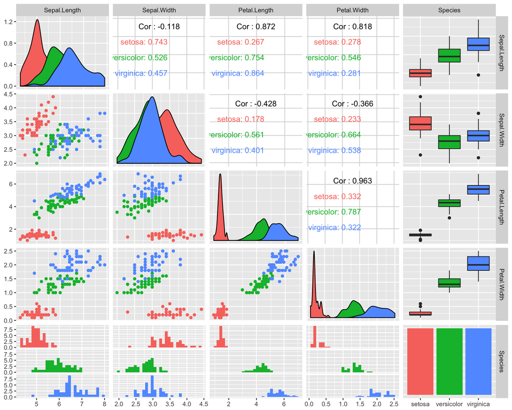

## Leading Questions…

- Petal dimensions important?
- Versicolor and Virginica separable?

### Decision Tree - rpart

[output not shown]

[output cut: 58 more lines]

```
      Sepal.Width  < 2.45 to the left,  improve= 3.555556, (0 missing)
  Surrogate splits:
      Petal.Length < 4.75 to the left,  agree=0.91, adj=0.804, (0 split)
      Sepal.Length < 6.15 to the left,  agree=0.73, adj=0.413, (0 split)
      Sepal.Width  < 2.95 to the left,  agree=0.67, adj=0.283, (0 split)

Node number 6: 54 observations
  predicted class=versicolor  expected loss=0.09259259  P(node) =0.36
    class counts:     0    49     5
   probabilities: 0.000 0.907 0.093

Node number 7: 46 observations
  predicted class=virginica   expected loss=0.02173913  P(node) =0.3066667
    class counts:     0     1    45
   probabilities: 0.000 0.022 0.978
```

### Decision Tree

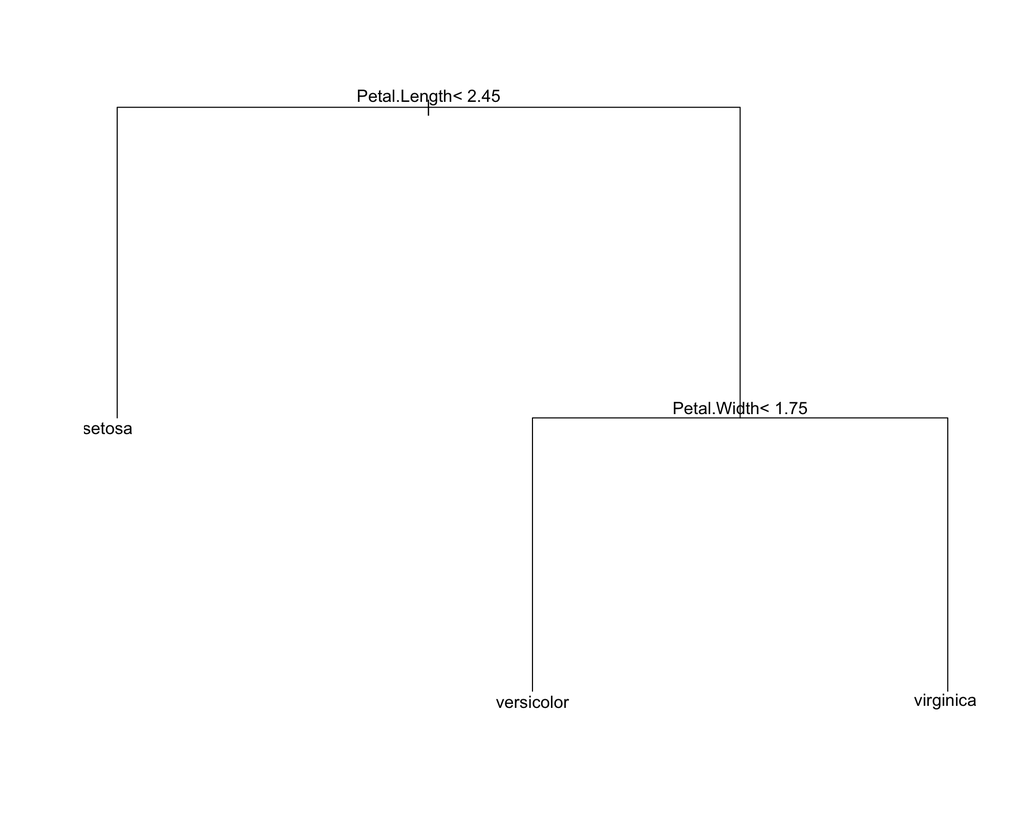

```r
plot(m$finalModel)
text(m$finalModel)
```

### Decision Tree

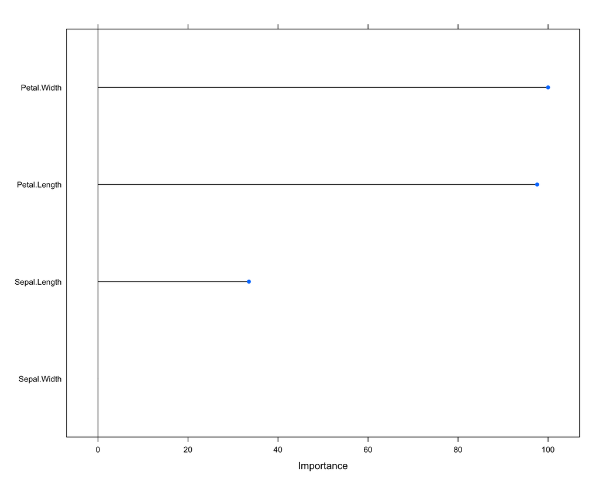

```r
plot(varImp(m))
```

Luckily, we can get a measure of the *importance* of each field according to the model.

- importance can be defined a number of different ways :
  - Reduction in MSE (used in rpart)
  - Accuracy
  - Gini metric
- importance does *not* imply positive or negative correlation

## Loss/Split Metrics

### Gini impurity

\[ G = \sum^{n_c}_{i=1}p_i(1-p_i) \]

- How often a randomly chosen element would be labeled *incorrectly* if it were labeled *randomly* according to current label distribution
- \( n_c \): number of classes
- \( p_i \): ratio of the class

### Information gain

\[ IG(Ex,a)=H(Ex) -\sum_{v\in values(a)} \left(\frac{|\{x\in Ex|value(x,a)=v\}|}{|Ex|} \cdot H(\{x\in Ex|value(x,a)=v\})\right) \] or \[ IG(T,a) = H(T) - H(T|a) \]

- \( H \) : entropy
- \( E_x \) : set of all attributes
- \( values(a) \) : set of all possible values for attribute
- In summary : if we hold one attibute to \( a \), how does this change the *information entropy*?
  - Also, what the heck is *information entropy*?

### Information Entropy

\[ H(X) = \sum_{i=1}^n {\mathrm{P}(x_i)\,\mathrm{I}(x_i)} = -\sum_{i=1}^n {\mathrm{P}(x_i) \log_b \mathrm{P}(x_i)} \]

- \( X \) : discrete random variable with \( {x_1, ..., x_n} \)
- \( P \) : probability mass function : \( f_X(x) = \Pr(X = x) = \Pr(\{s \in S: X(s) = x\} \)
  - all values are non-negative and sum to 1
- \( I(X) \) : Information content of \( X \)
- \( b \) : logarithm base (usually 2 - gain expressed in bits)

### Information Entropy

```r
eta = function(h){
  t = 1-h
  - ((h * log2(h)) + (t * log2(t)))
}
```

- information is at maximum when entropy (eta) at maximum
- log scaling (by log 2) gives *unit* on a fair coin flip (i.e. think in bits)

```r
# odds of flipping heads
heads = (0:10)/10
heads
```

```
 [1] 0.0 0.1 0.2 0.3 0.4 0.5 0.6 0.7 0.8 0.9 1.0
```

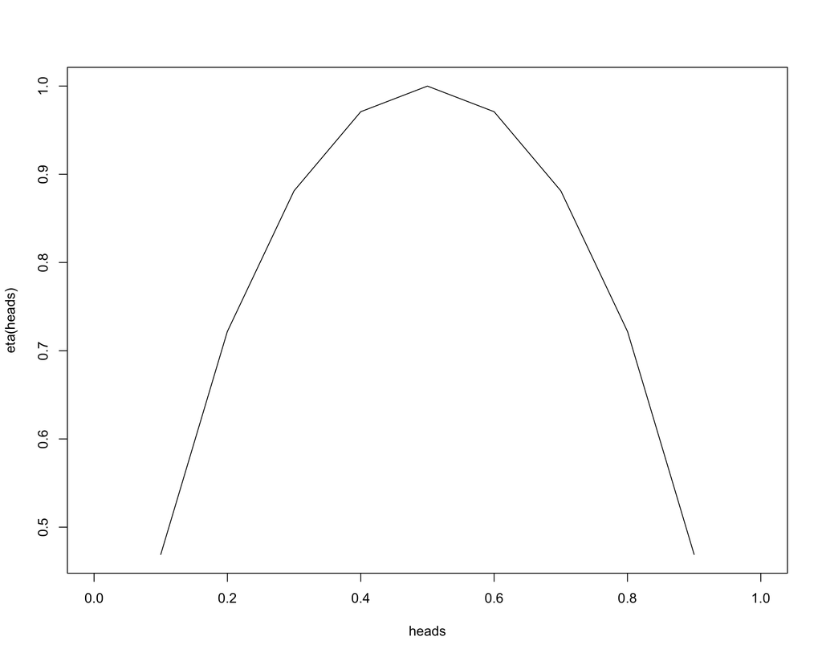

```r
plot(heads,eta(heads), type='l')
```

### Information Entropy

Splitting algorithm seeks *minimal entropy* splits

- each branch should have biased (homogeneous) likelihoods for certain classes
- maximizing on information gain at each split point ensures tree depth is minimal

### Information gain

- *Overemphasizes fields with large numbers of labels* - Why?
  - Fix this by taking “top n” labels (which can reduce accuracy)
  - Fix this by taking *information gain ratio*, which requires normalizing by *intrinsic value*

### Intrinsic value

\[ IV(Ex,a)= -\sum_{v\in values(a)} \frac{|\{x\in Ex|value(x,a)=v\}|}{|Ex|} \cdot \log_2\left(\frac{|\{x\in Ex|value(x,a)=v\}|}{|Ex|}\right) \]

- the denomintor in Information gain ratio
- establish a value

### Variance reduction

## What if we want to handle *regression* trees?

\[ I_{V}(N) = \frac{1}{|S|^2}\sum_{i\in S} \sum_{j\in S} \frac{1}{2}(x_i - x_j)^2 - \left(\frac{1}{|S_t|^2}\sum_{i\in S_t} \sum_{j\in S_t} \frac{1}{2}(x_i - x_j)^2 + \frac{1}{|S_f|^2}\sum_{i\in S_f} \sum_{j\in S_f} \frac{1}{2}(x_i - x_j)^2\right) \]

- \( S,S_t,S_f \) : set of presplit sample indices
- Minimize the mean squared error of the two branches with a given split

## Misc Tree Methods

### Partition Tree

A nice option if you have exactly 2 input dimensions

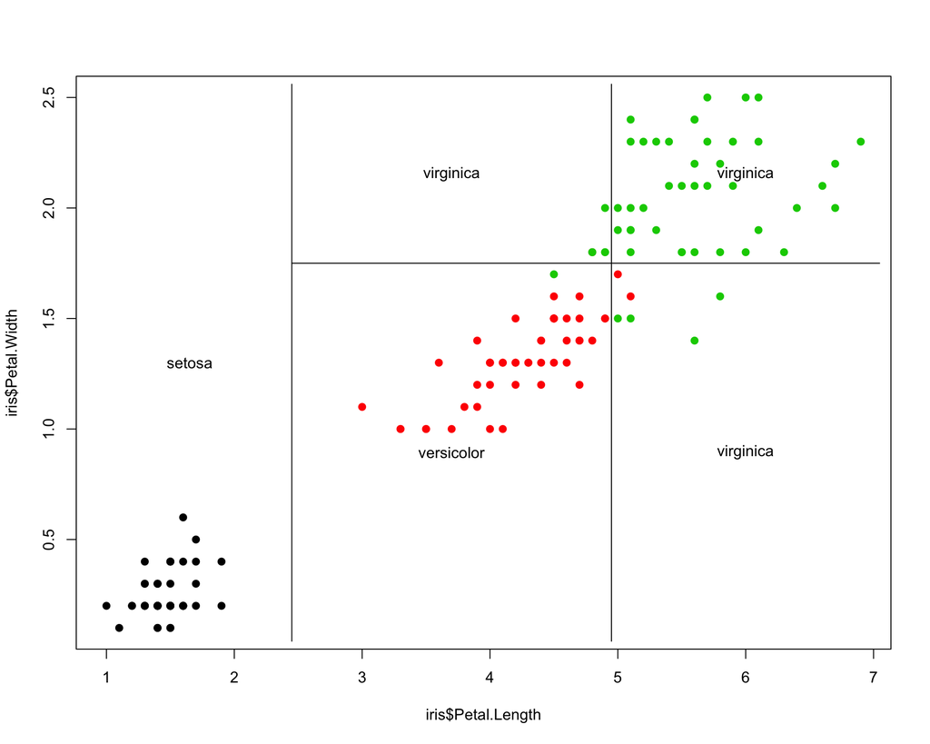

### Looking into Iris

```r
data(iris)
iris.rf <- randomForest(Species ~ ., iris, importance=T)
iris.rf
```

```
Call:
 randomForest(formula = Species ~ ., data = iris, importance = T)
               Type of random forest: classification
                     Number of trees: 500
No. of variables tried at each split: 2

        OOB estimate of  error rate: 4.67%
Confusion matrix:
           setosa versicolor virginica class.error
setosa         50          0         0        0.00
versicolor      0         47         3        0.06
virginica       0          4        46        0.08
```

### Looking into Iris

```r
# get tree #23 from the model
getTree(iris.rf,k=23)
```

```
   left daughter right daughter split var split point status prediction
1              2              3         1        5.55      1          0
2              4              5         4        0.80      1          0
3              6              7         3        4.75      1          0
4              0              0         0        0.00     -1          1
5              0              0         0        0.00     -1          2
6              8              9         3        2.60      1          0
7             10             11         2        2.95      1          0
8              0              0         0        0.00     -1          1
9              0              0         0        0.00     -1          2
10             0              0         0        0.00     -1          3
11            12             13         2        3.25      1          0
12            14             15         4        1.75      1          0
13             0              0         0        0.00     -1          3
14             0              0         0        0.00     -1          2
15            16             17         3        4.85      1          0
16            18             19         2        3.10      1          0
17             0              0         0        0.00     -1          3
18             0              0         0        0.00     -1          3
19             0              0         0        0.00     -1          2
```

Unfortunately, it's very difficult to inspect individual trees, or form an understanding of how they reach consensus on a given case.

### Looking into Iris

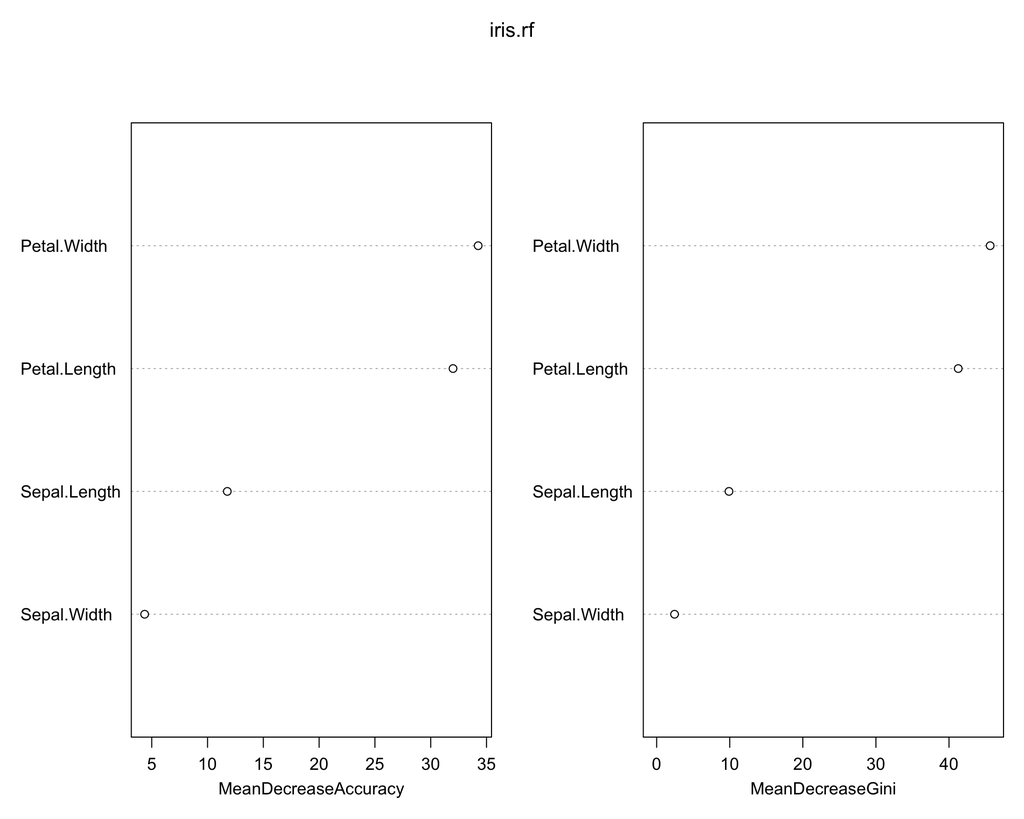

```r
varImpPlot(iris.rf)
```

### Example : Tweak one variable while holding training set fixed

```r
irisTweak = function(var){
  dummy = iris
  idx = seq(min(dummy[var]), max(dummy[var]), by=.01)
  probs = sapply(idx, function(x) {
    dummy[var] = x;
    apply(predict(iris.rf, dummy, type='prob'),2,mean)
  })
  dat = as.data.frame(t(apply(probs,2,unlist)))
  dat[var] = idx;
  dat = melt(dat, id.vars=var)
  colnames(dat)[colnames(dat) == 'value'] <- 'probability'
  ggplot(dat, aes_string(x=var, y='probability', color='variable')) +
    geom_line(alpha=.8, aes(size=2)) + guides(size=F)
}
# E.g.
#irisTweak("Petal.Length")
```

### Example : Tweak Petal.Length while holding training set fixed

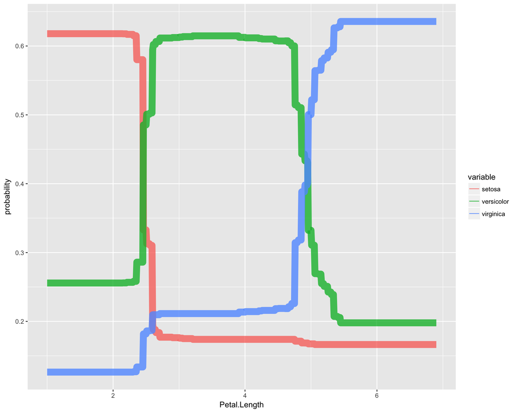

### Example : Tweak Petal.Width while holding training set fixed

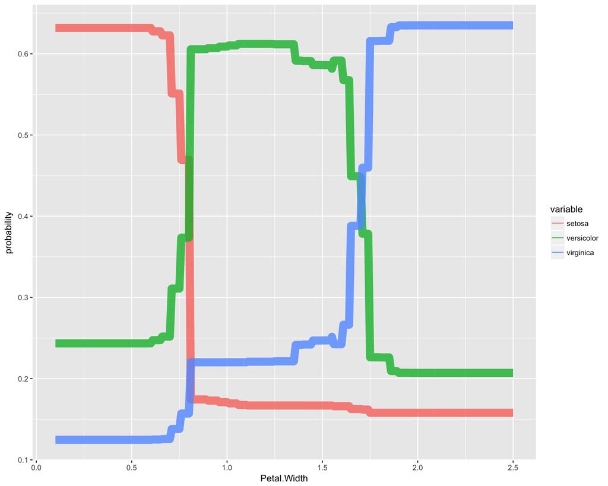

### Example : Tweak Sepal.Length while holding training set fixed

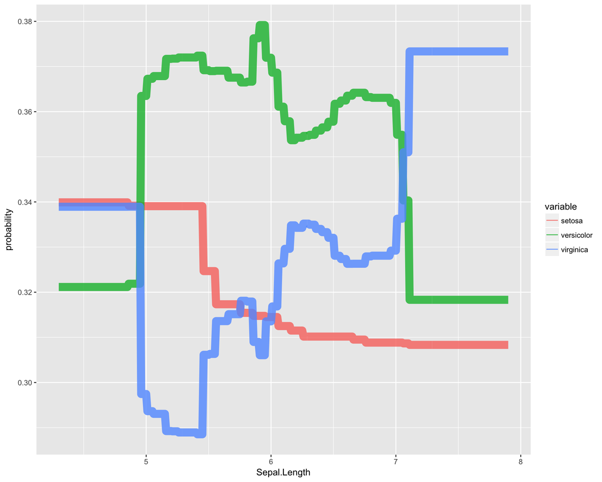

### Example : Tweak Sepal.Width while holding training set fixed

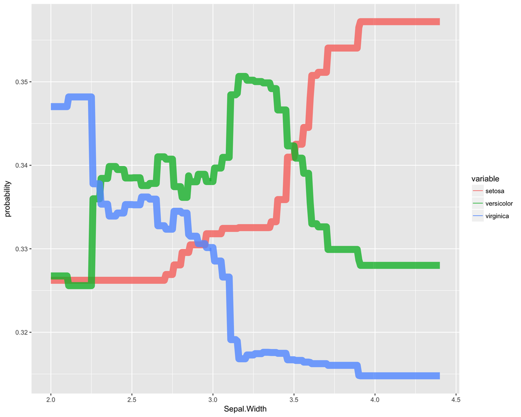